# Calculus overview

Differential equations

Dr. Le Nhat Tan

# Two principal symbols in calculus

# Differential sign: $d$

- $d$ means a little bit of something
- $dx$, called differential of $x$, means a little bit of a quantity $x$.
- $dx$ can be understood as the smallest positive quantity.
- Any positive quantity that is smaller than $dx$ can be ignored (that quantity can be considerd as 0). As a result, $dx^{\alpha}=0, \forall \alpha>1$.

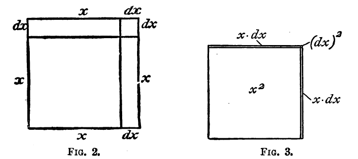

# Integral sign: $\int$

- The sign $\int$ represents a long $S$.
- $\int$: the sum of something.
- $\int dx$: the sum of all the little bit of $x$.
- $\int dx=x$: the sum of all the little bit of $x$ equals to $x$.

# Comparing quantities

# Example 1

Consider the following triangle. Let $x$ and $y$ be respectively the base and height of a right-angle triangle, of which the slope of the other side is fixed at $30^0$. If we expand the triangle and keep its angles the same as at first, then when the base grows to $x+dx$, the height becomes $y+dy$. Find the relationship between $dy$ and $dx$.

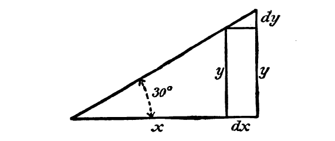

# Example 2

Let $x$ be the horizontal distance, from a wall, of the foot of a ladder $AB$, of fixed length; and $y$ be the height it reaches the up the wall. It is clear that if we move the bottom end $A$ as a bit further from the wall, the top end $B$ will come down a little lower. In other words, if we change $x$ to $x+dx$, then $y$ will change accordingly to $y+dy$. Find the ratio $\dfrac{dy}{dx}$.

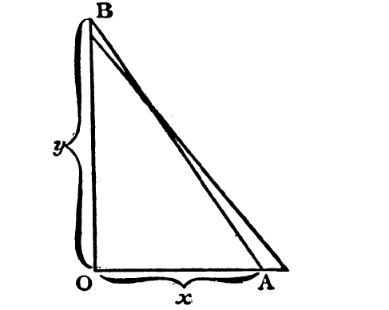

# Introduction to Slope

**Slope** is a fundamental concept in mathematics that describes the steepness, incline, or gradient of a line. In everyday terms, slope tells us how quickly something is changing.

# The Mathematics of Slope

# Definition

For a straight line passing through two points $(x_1, y_1)$ and $(x_2, y_2)$, the slope $m$ is defined as:

$$m = \frac{\text{rise}}{\text{run}} = \frac{y_2 - y_1}{x_2 - x_1} =
\frac{\Delta y}{\Delta x}$$

Where: - $\Delta$ (Delta) means “change in” - $\Delta y = y_2 - y_1$ = vertical change - $\Delta x = x_2 - x_1$ = horizontal change

# Visualizing Slope

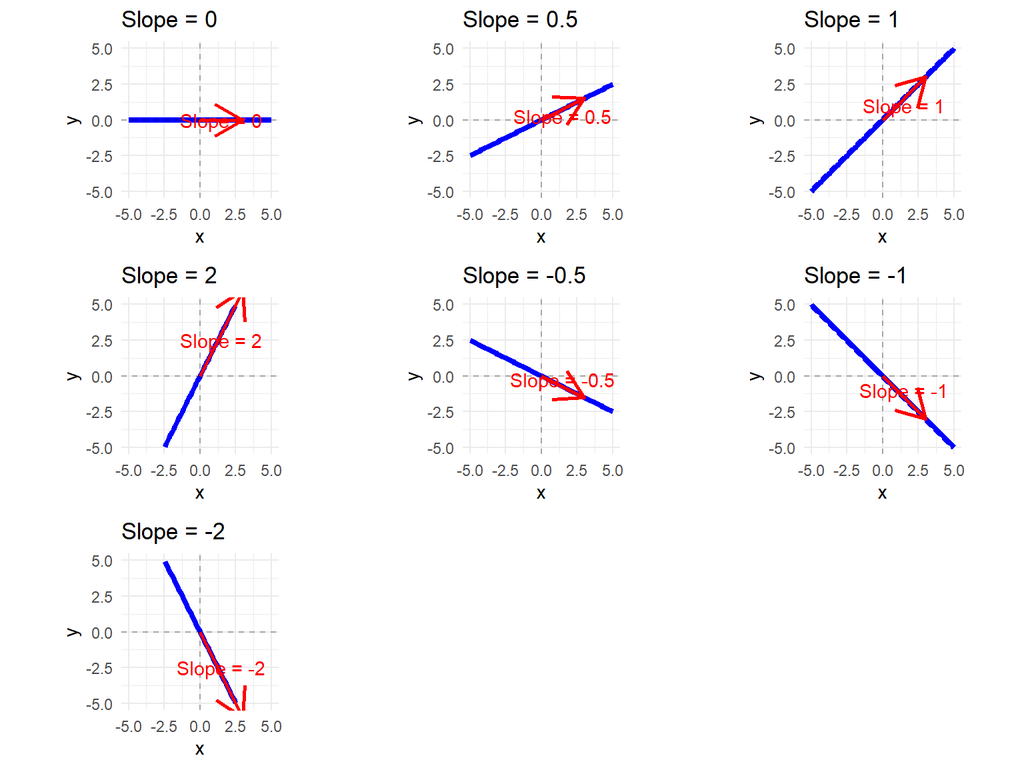

# Types of Slope

Types of Slope

| Type | Description | Value | Example |
| --- | --- | --- | --- |
| Positive Slope | Line rises from left to right | m > 0 | y = 2x + 1 |
| Negative Slope | Line falls from left to right | m < 0 | y = -3x + 4 |
| Zero Slope | Horizontal line (no vertical change) | m = 0 | y = 5 |
| Undefined Slope | Vertical line (no horizontal change) | m = undefined | x = 3 |

# Calculating Slope: Interactive Examples

```
##
## ### Interactive Slope Calculator
##
## Enter coordinates of two points:
##
## Point 1: (x₁, y₁) = (2, 3)
## Point 2: (x₂, y₂) = (5, 11)
##
## Slope calculation:
## m = (y₂ - y₁) / (x₂ - x₁)
##   = (11 - 3) / (5 - 2)
##   = 8 / 3
##   = 2.6667
##
## The line rises 2.67 units vertically for every 1 unit horizontally.
```

# Derivative Definition

The derivative of a function at a point $x_0$ is defined as:

$$f'(x_0) = \lim_{x \to x_0}
\frac{f(x) - f(x_0)}{x - x_0} = \lim_{\Delta x \to 0} \frac{\Delta
y}{\Delta x}$$

Where $\Delta x = x - x_0$

The slope of the tangent line is $f'(x_0)$.

# Fundamental Theorem of Calculus

If $f'(x) = F(x)$, then:

$$\int F(x) dx = f(x) + C$$

# Derivatives of Simple Functions

# Power Function

$$(x^n)' = n \cdot x^{n-1}$$
Special case: $(x)' = 1$

# Exponential and Constant Functions

$$(e^x)' = e^x$$
$$(c)' = 0 \quad \text{where c is a
constant}$$

# Trigonometric Functions

$$(\sin x)' = \cos x$$
$$(\cos x)' = -\sin x$$
$$(\tan x)' = \sec^2 x$$

# Differentiation Rules

# Product Rule

$$[f(x) \cdot g(x)]' = f'(x) \cdot
g(x) + f(x) \cdot g'(x)$$

# Example

Compute $(e^x \cdot \sin x)'$

# Solution

$$(e^x \cdot \sin x)' = (e^x)'
\sin x + e^x (\sin x)'$$
$$= e^x
\sin x + e^x \cos x$$
$$= e^x (\sin x
+ \cos x)$$

# Quotient Rule

$$\left(\frac{f(x)}{g(x)}\right)' =
\frac{f'(x) \cdot g(x) - f(x) \cdot
g'(x)}{[g(x)]^2}$$

# Example

Compute $(\tan x)'$

# Solution

$$(\tan x)' = \left(\frac{\sin x}{\cos
x}\right)'$$
$$= \frac{\cos x
\cdot \cos x - \sin x \cdot (-\sin x)}{\cos^2 x}$$
$$= \frac{\cos^2 x + \sin^2 x}{\cos^2 x}$$
$$= \frac{1}{\cos^2 x} = \sec^2
x$$

# Chain Rule

$$[f(g(x))]' = f'(g(x)) \cdot
g'(x)$$

# Example

1. Compute $\frac{d}{dx}(e^{kx})$
2. Compute $\frac{d}{dx}(e^{\sin x} + e^x \cdot \cos x)$

# Solution 1

$$\frac{d}{dx}(e^{kx}) = \frac{d}{du}(e^u)
\cdot \frac{du}{dx} \quad \text{where } u = kx$$
$$= e^u \cdot k = k \cdot e^{kx}$$

# Solution 2

$$f(x) = e^{\sin x} + e^x \cdot \cos
x$$
$$f'(x) = \frac{d}{dx}(e^{\sin
x}) + \frac{d}{dx}(e^x \cos x)$$
$$=
e^{\sin x} \cdot \cos x + [(e^x)' \cos x + e^x (\cos
x)']$$
$$= e^{\sin x} \cdot \cos x
+ [e^x \cos x + e^x (-\sin x)]$$
$$=
e^{\sin x} \cdot \cos x + e^x \cos x - e^x \sin x$$